# Model Optimization

Ernesto Carrella

November 30, 2015

## The End Game

Eventually we build our policy simulator to find the best policy possible. If you think of the java model as a black-box function where the input is the policy and the output is a score of how much we like its end state, you can think of finding the best policy as a function optimization problem.  
Currently we are using a Bayesian Optimization algorithm to optimize our simulation. Bayesian optimization has the benefit of weighing the uncertainty of each simulation run and moving quite quickly to good parameters. Unfortunately all implementations that are available use only single-objective algorithms which mean that we can score our simulation on only one dimension (or a scalar combination of dimensions).

## Separated World

There are 2 kinds of fish: the red species lives on the north part of the sea, and blue fishes live south. We want to find the policy that incentivates the catching of red fish and the conservation of blue fish. We therefore score a simulation as follows:
$$\text{Score} = \text{Blue Biomass Left} + \sum_{i=1}^T \text{Red Catches at Year } i$$
We run the simulation for $T=20$ years and try to find the best policy that maximizes the score.

First, let’s focus on simple TAC: set up a total quota for each species and whenever either is consumed the season ends. We run the simulation 200 times, letting the algorithm suggest the quota levels to use for each simulation. In th next plots each dot represents a run, the first plot shows the expected “score” of running a new simulation with a particular quota regime, the second plots shows our uncertainty range on the expected score.

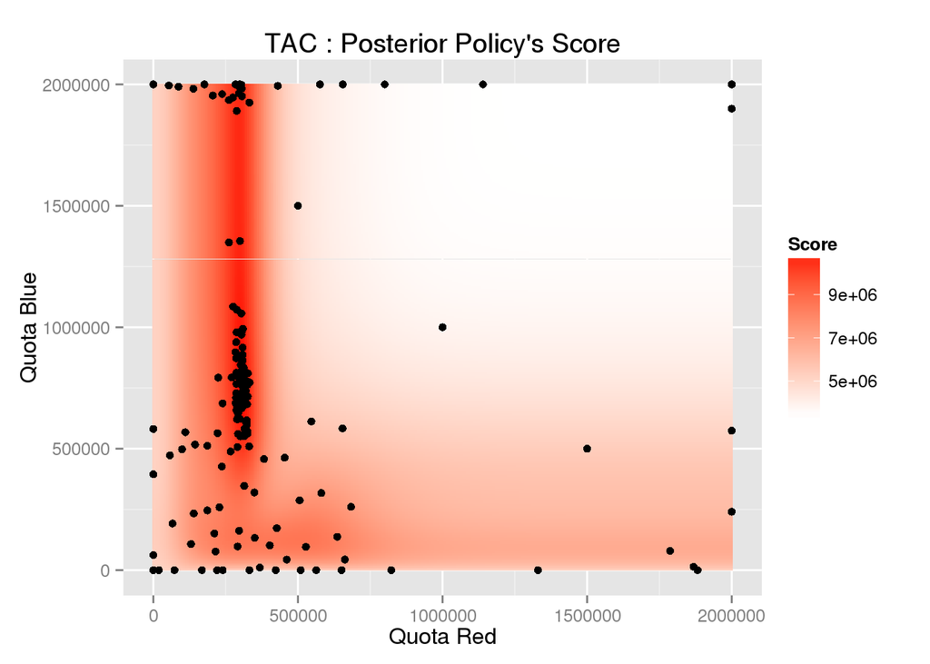

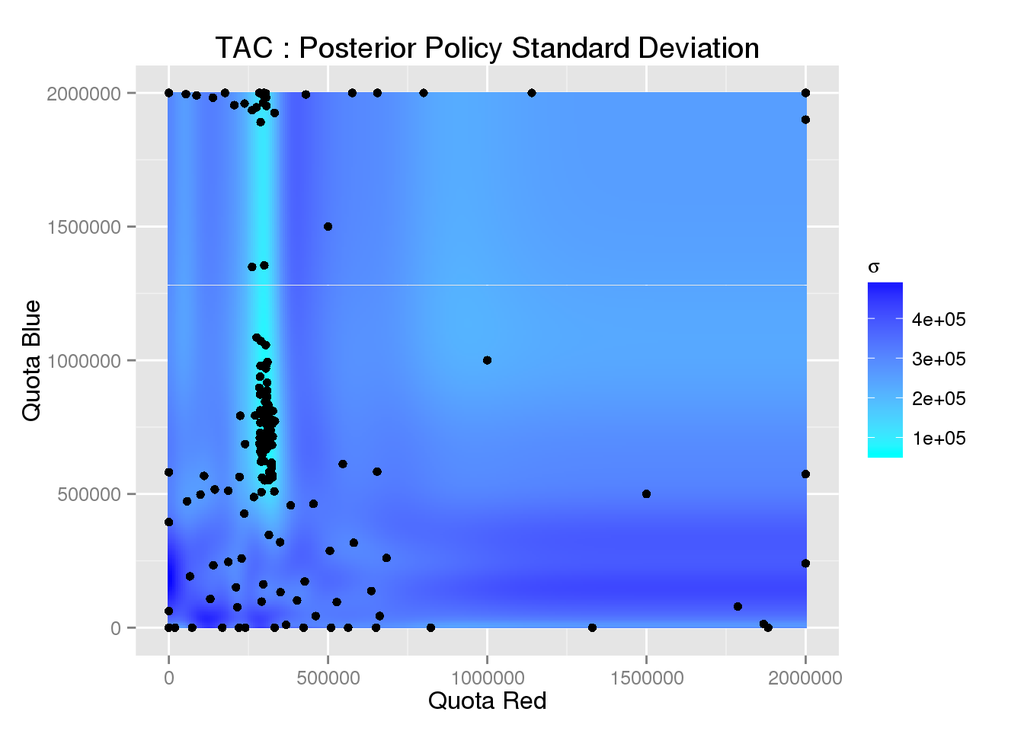

A very different policy is suggested if we use ITQs instead.

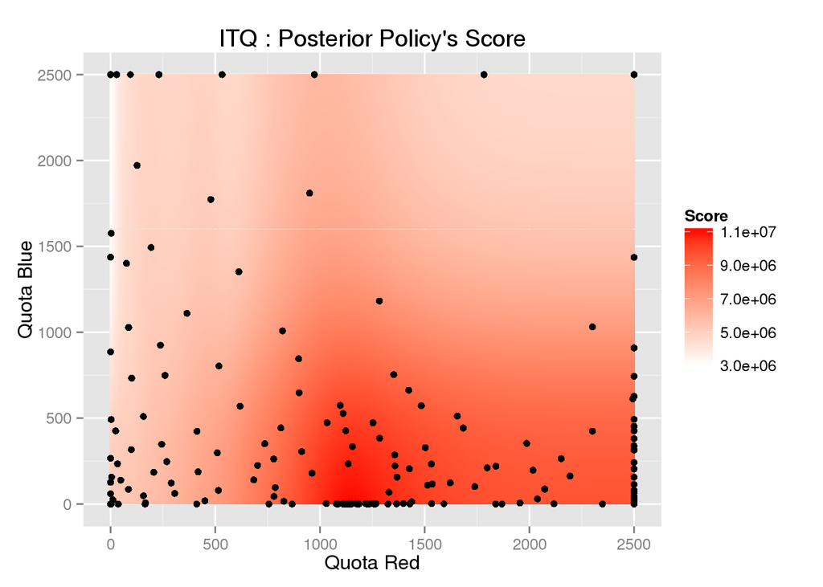

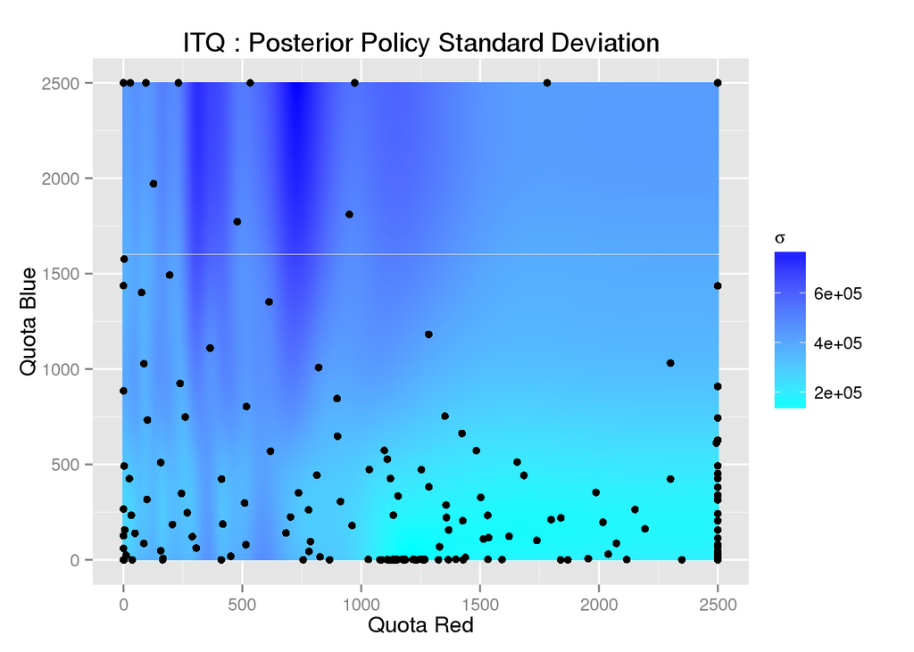

As you can see from the graphs, most simulations run around the blue quotas $=0$ axis. In fact the maximum score is predicted by the bayesian algorithm to be achieved by giving 1,175 lbs of red fish quota to each fisher and no blue quota. Interestingly then, the optimal policy in a perfectly separated world is “**one strike and you are out** (for a season)” policy.  
This is a result of the way ITQs in our java model influence agents’ fishing locations while global TACs don’t.

The main message here is that if we are to allocate quotas, ITQs should not be structured just as parcellized TACs but should also take into consideration how individual incentives modify fishing decisions.

## Well-Mixed World

If the world is purely mixed (each cell contains red-to-blue fish ratio of 80%), the ITQ incentives aren’t particularly useful as agents don’t really have any way to modulate their blue versus red catches.  
It is no surprise then that in this case TACs and ITQs solutions are very similar.

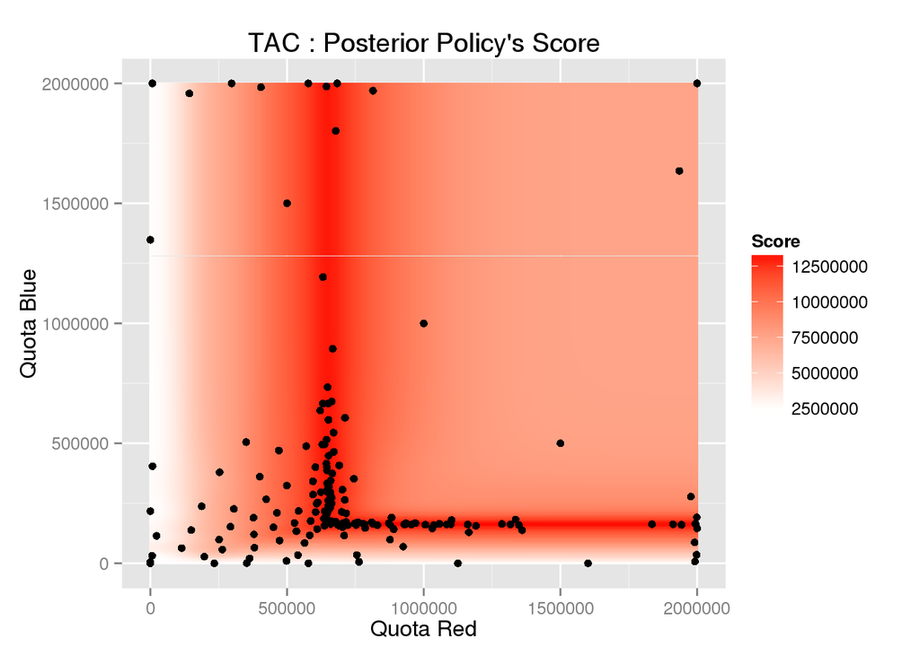

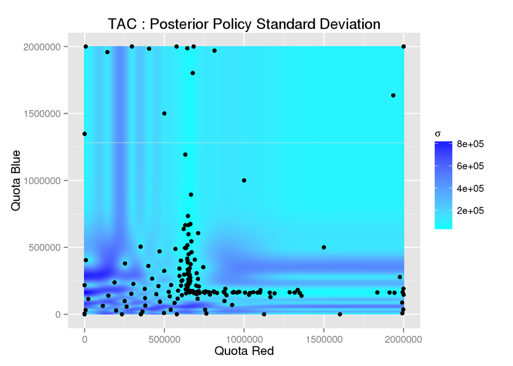

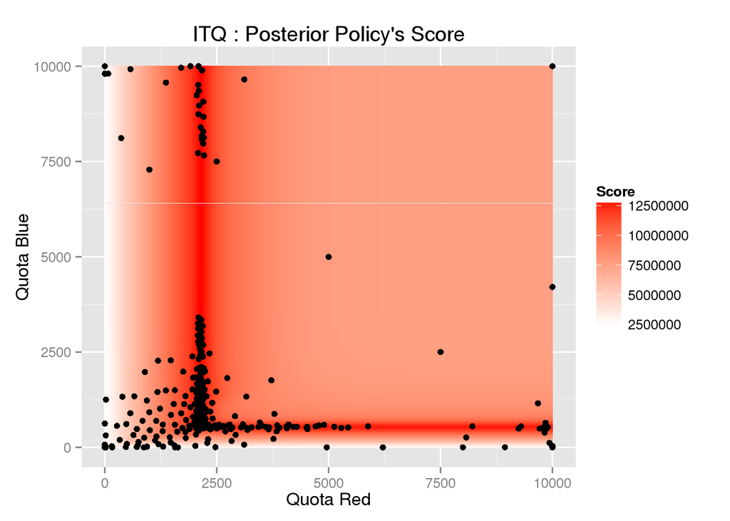

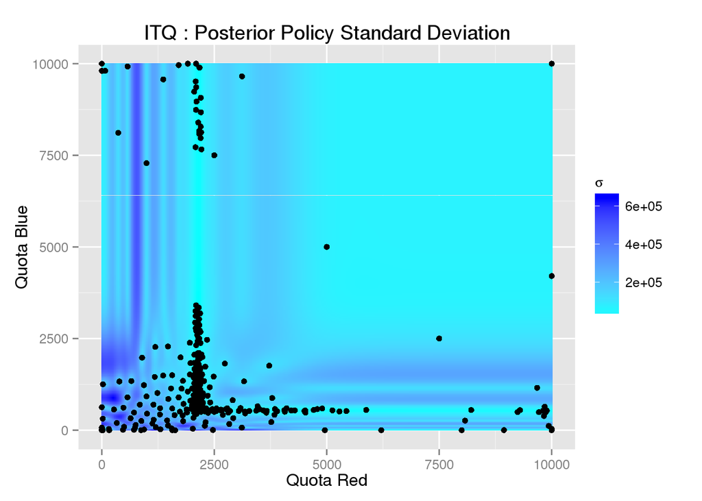

Notice the shape of the solution: a [“leontief-like”](http://cruel.org/econthought/essays/product/image/technol1.gif). This is a result of the well-mixing of the world.

## What is left to be done

Besides a few more scenarios (which might include season-length and MPAs) I think the main weakness of this approach is that we need to express the tradeoff in a single score function that is necessarilly arbitrary (how many more fish in the sea is a drop of 5% in income inequality worth?). It would be better to have a full multi-objective optimization algorithm running so as to generate a full pareto-front but unfortunately no multi-objective Bayesian algorithm is available just yet. I might try a genetic algorithm for this but we’d lose all the advantages of Bayesian optimization.